# Basic Table Summarizing and Manipulation

Chris Luke

# Set Up

Change `author: YOUR_NAME_HERE` in the header to your name accordingly for example I would do `author: Chris Luke`

Notes: you should have mosaic and rmarkdown packages installed.

To check copy this code to the console and run it:

```r
c("mosaic", "rmarkdown") %in% installed.packages()
```

You should get a line with “[1] TRUE TRUE”. The first TRUE is for mosaic and the second TRUE is for rmarkdown. If you get a FALSE you need to run install the packages this code will install both the packages:

```r
install.packages(c("mosaic", "rmarkdown"))
```

To turn in this assignment we are going to “knit” it into a PDF for that we need tinytex. To check if tinytex is installed run this in the console:

```r
tinytex::is_tinytex()
```

You should get “[1] FALSE” if tinytex isn’t installed. If you get TRUE then you don’t need to install tinytex and can skip ahead.

We install tinytex by running this code in the console:

```r
tinytex::install_tinytex()
```

Now ``tinytex::is_tinytex()`` should return TRUE

# Loading mosaic

There should be code chunk that loads mosaic first thing in your “worksheet”. We are going to always need to load mosaic, if it has been loaded this doesn’t do anything, but if it hasn’t it loads it. We don’t have to load rmarkdown or tinytex because while we are using them they are used differently.

To use the worksheet we are going to put/edit code in the chunks then we will run them, by hitting the green play button to their right. Following along with these slides.

# mosaicData

Mosaic includes mosaicData we are going to use the data sets in includes to do some summarizing, Table Manipulation and plotting.

Run this code in the console a help page should open with all the Data Sets. You may want to look though them, Birthdays in particular. then come back to the viewer table to continue.

```r
help(package = "mosaicData")
```

# Filtering a table

So we are going to filter Birthdays using `filter(...)` to get the state of CA like this:

```r
data %>% filter(<name> == <value>)
```

`data` is the data we are filtering and `<name>` should be the name of the column we want to filter on and `<value>` is the value we want to compare it with. So we get the following:

```r
Birthdays %>% filter(state == "CA")
```

Try running this in the console. you should get a number of rows of this table all printed out.

# More Filtering

That filtered it to just CA but we want just CA in 1980. Edit this code for #1 in the worksheet, replacing `<name>` and `<value>` to get just CA in 1980. Note: the value is a number here so no quotes.

```r
Birthdays %>% filter(state == "CA", <name> == <value>)
```

Finally run it to see what you get.

# Assigning Variables

Now we want to put our filtered data into a variable to use it again. There are two ways of doing this `a -> b` and `a <- b`.

- `a -> b` stores a in variable b
- `a <- b` makes a variable a then puts b in it.

Since we already had something on the line for #1 we can just add `-> filteredBirthdays` to the end like this:

```r
Birthdays %>% filter(state == "CA", <name> == <value>) -> filteredBirthdays
```

# Simple Summarizing

Now lets find the total number of birthdays in CA in 1980, we use sum() to do this first we need to tell sum to use filteredBirthdays as it’s data, then we need to tell it what to add up with a “formula” they look like `~ <thing>` Replace `<thing>` with `births` because that’s what we want to add up.

```r
sum(data = filteredBirthdays, ~ <thing>)
```

There are several other functions that have the same layout:

`func(data = <dataset>, <formula>)` or `func(<formula>, data = <dataset>)`

- fivenum: returns Tukey’s five number summary
- quantile: returns quartiles by default
- IQR: computes interquartile range based on quartiles
- var: computes the sample Variance
- sd: computes the sample standard deviation

These should be self explanatory: median, max, mean, min, prod, range, sum

# Advanced Summarizing

summarize(..) is a helpful function that can build us a new table from an old by summarizing, note for fivenum and quantile because they return multiple values we have to take care of that or we will get odd results.

Run ex#1 to see it in action. hit the right arrow and check if the values match up with the ones from #2

But, this output is kind of boring so let try grouping by something first, group_by(…) will do this for us so try replacing in number 3 `<group>` so we group by state. Then we use summarize to sum up the births.

```r
Birthdays %>%
  group_by(<group>) %>%
  summarise(births = sum(births))
```

# Table Sorting

Now lets look at what state had the least or most variance in births.

Look at the code for #4 and replace `<group>` and `<func>` with the right things

```r
Birthdays %>%
  group_by(<group>) %>%
  summarise(variance = <func>(births)) %>%
  arrange(desc(variance))
```

Replace the ____ with the states that had the most and least variance

- Most: ____
- Least: ____

# Puting it together Filter, Group and Summarise

Now what if we wanted to know the `sum` of births per month in CA in 1980? Replace the things in angle brackets so we get the `sum` of births per month in CA in 1980, for number 5. Then run it you should get a nice table.

```r
Birthdays %>%
  filter(<name> == <value>, <name> == <value>) %>%
  group_by(<group>) %>%
  summarise(births = <func>(<thingTosummarise>))
```

# Ploting our table

First copy your number 5 to number 6 replacing `<NUMBER5>`. Now lets make a column plot of this data, `gf_col(...)` does what we want but it’s formula takes two things we plot one thing in respect to another. so it’s formula looks like: `<y> ~ <x>`. So we can start with our raw data set send it to a filter, group it, summarize it, then plot it by just sending it from one thing to another. So add `%>% gf_col(<y> ~ <x>)` to the end of number 5 for number 6. Then replace `<y>` and `<x>` so we get a column plot of births per month. Hint: if you get lots of skinny tall lines swap your `<y>` and `<x>`.

```r
Birthdays %>%
  filter(<name> == <value>, <name> == <value>) %>%
  group_by(<group>) %>%
  summarise(births = <func>(<thingTosummarise>)) %>%
  gf_col(<y> ~ <x>)
```

# Example Plot A:

Points for births by the day of the year

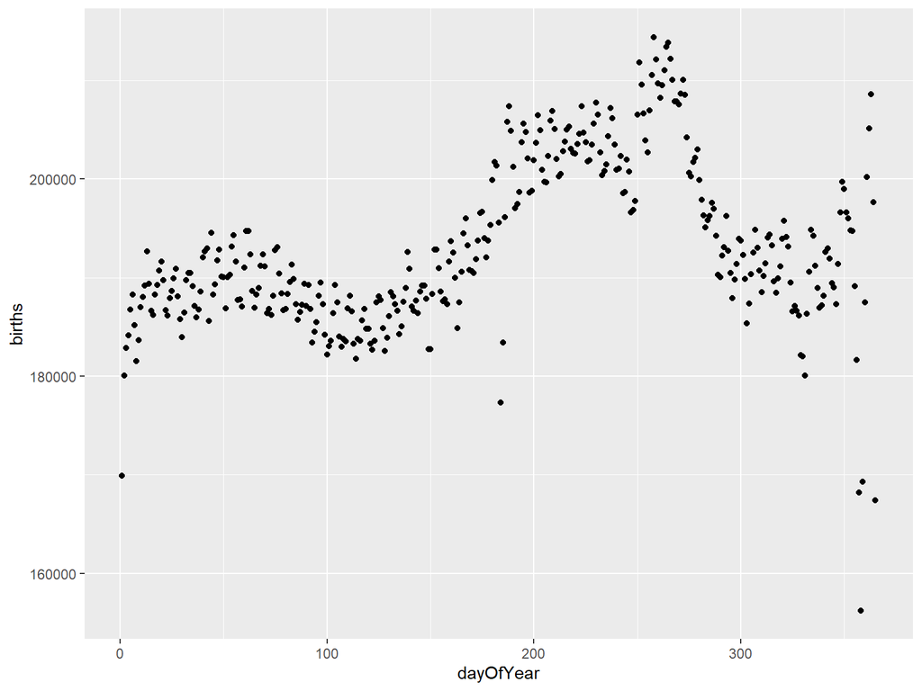

```r
Birthdays %>%
  mutate(
    #strftime is a function for formatting dates here we get just the dayOfYear
    dayOfYear = as.numeric(strftime(date, format = "%j"))
  ) %>%
  #lets remove the last day of leap years so we can see the other days clearly
  filter(dayOfYear <= 365) %>%
  group_by(dayOfYear) %>%
  summarise(births = sum(births)) %>%
  gf_point(births ~ dayOfYear)
```

# Example Plot B:

Or a line plot with births by day of the week:

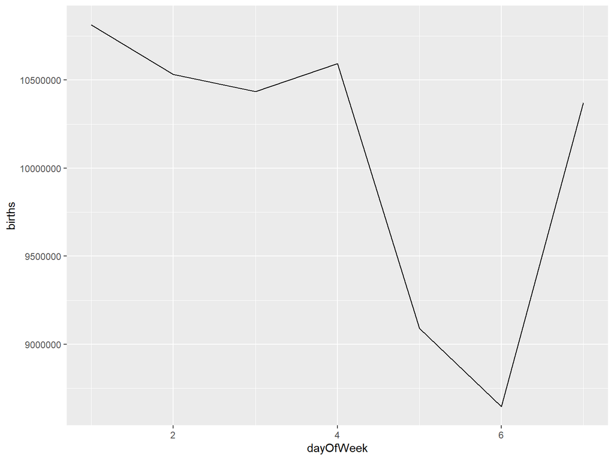

```r
Birthdays %>%
  mutate(
    #strftime is a function for formatting dates here we get just the dayOfWeek
    dayOfWeek = as.numeric(strftime(date, format = "%u"))
  ) %>%
  group_by(dayOfWeek) %>%
  summarise(births = sum(births)) %>%
  gf_path(births ~ dayOfWeek)
```

# Finshing:

Now after you have read/ran everything and following the instructions, and replaced all the `<things>` correctly in the previous sections. At the top left of the editor panel in RStudio there is a button that says “Knit” or “Preview” click the arrow to the right of it then click “Knit to PDF” R will make a PDF of this notebook, that’s what you will turn in. Don’t forget to change the author at the very top to your name.